# Machine Learning Assignment

Sanaz Dehghani

6/10/2021

##Summary One thing that people regularly do is quantify how much of a particular activity they do, but they rarely quantify how well they do it. In this Report, Our goal is to use data from accelerometers on the belt, forearm, arm, and dumbell of 6 participants and predicting the manner in which they did the exercise.To achieve this, we tailor a best model for prediction and predict classe parameter for 20 given sample.

##Geting and Cleaning Data first we load required libraries.

```r
library(caret)
library(dplyr)
library(rpart)
```

```r
library(rpart.plot)
library(RColorBrewer)
library(rattle)
library(randomForest)
library(e1071)
library(corrplot)
library(gbm)
```

We download and store training and testing data.

```r
trainingdata<-read.csv(url("https://d396qusza40orc.cloudfront.net/predmachlearn/pml-training.csv"),header=TRUE)
str(trainingdata)
```

```
## 'data.frame':    19622 obs. of  160 variables:
##  $ X                       : int  1 2 3 4 5 6 7 8 9 10 ...
##  $ user_name               : chr  "carlitos" "carlitos" "carlitos" "carlitos" ...
##  $ raw_timestamp_part_1    : int  1323084231 1323084231 1323084231 1323084232 1323084232 1323084232 1323084232 1323084232 1323084232 1323084232 ...
##  $ raw_timestamp_part_2    : int  788290 808298 820366 120339 196328 304277 368296 440390 484323 484434 ...
##  $ cvtd_timestamp          : chr  "05/12/2011 11:23" "05/12/2011 11:23" "05/12/2011 11:23" "05/12/2011 11:23" ...
##  $ new_window              : chr  "no" "no" "no" "no" ...
##  $ num_window              : int  11 11 11 12 12 12 12 12 12 12 ...
##  $ roll_belt               : num  1.41 1.41 1.42 1.48 1.48 1.45 1.42 1.42 1.43 1.45 ...
##  $ pitch_belt              : num  8.07 8.07 8.07 8.05 8.07 8.06 8.09 8.13 8.16 8.17 ...
##  $ yaw_belt                : num  -94.4 -94.4 -94.4 -94.4 -94.4 -94.4 -94.4 -94.4 -94.4 -94.4 ...
##  $ total_accel_belt        : int  3 3 3 3 3 3 3 3 3 3 ...
##  $ kurtosis_roll_belt      : chr  "" "" "" "" ...
##  $ kurtosis_picth_belt     : chr  "" "" "" "" ...
##  $ kurtosis_yaw_belt       : chr  "" "" "" "" ...
```

[output cut: 86 more lines]

```r
testingdata<-read.csv(url("https://d396qusza40orc.cloudfront.net/predmachlearn/pml-testing.csv"),header=TRUE)
dim(testingdata)
```

```
## [1]  20 160
```

As we see in a summary, we have lots of empty and missed values so we remove columns which have many of them and dont add values for prediction in training data and test data.

```r
removedcols <- which(colSums(is.na(trainingdata) |trainingdata=="")>0.9*dim(trainingdata)[1])
cleantrainingdata <- trainingdata[,-removedcols]
cleantrainingdata <- cleantrainingdata[,-c(1:7)]
dim(cleantrainingdata)
```

```
## [1] 19622    53
```

```r
removedcols <- which(colSums(is.na(testingdata)|testingdata=="")>0.9*dim(testingdata)[1])
cleantestdata <- testingdata[,-removedcols]
cleantestdata <- cleantestdata[,-c(1:7)]
dim(cleantestdata)
```

```
## [1] 20 53
```

```r
NZV <- nearZeroVar(cleantrainingdata)
rm(NZV)
```

# Partitioning Training Data

We set a seed for reproduce ability.

```r
set.seed(105137)
```

now we partition our training data to 60% as training data and 40% for test.

```r
train <- createDataPartition(cleantrainingdata$classe, p = 0.6, list = FALSE)
traindata <-cleantrainingdata[train, ]
testdata <-cleantrainingdata[-train, ]
dim(traindata)
```

```
## [1] 11776    53
```

##Explatory Data Analysis we draw Correlation Matrix of Columns in the Training Data set.

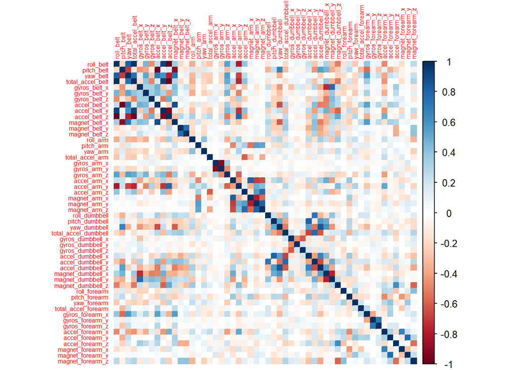

```r
corrplot(cor(traindata[, -length(names(traindata))]), method = "color", tl.cex = 0.5)
```

we see variables with high correlation (near 1 and -1) with dark blue and red. ## Prediction We use Random Forest, Decision Trees and Generalized Boosted Model for prediction model selection. we also use cross validation method for improving efficiency of models with 5 folds. #Random Forests

```r
fitcontrol<-trainControl(method = "cv", number=5)
RF <- train(classe ~ ., data = traindata, method = "rf", trControl =fitcontrol, verbose=FALSE)
RF
```

```
## Random Forest
##
## 11776 samples
##    52 predictor
##     5 classes: 'A', 'B', 'C', 'D', 'E'
##
## No pre-processing
## Resampling: Cross-Validated (5 fold)
## Summary of sample sizes: 9420, 9420, 9421, 9420, 9423
## Resampling results across tuning parameters:
##
##   mtry  Accuracy   Kappa
##    2    0.9899795  0.9873222
##   27    0.9900644  0.9874309
##   52    0.9825915  0.9779741
##
## Accuracy was used to select the optimal model using the largest value.
## The final value used for the model was mtry = 27.
```

#Decision Tree

```r
fitcontrol<-trainControl(method = "cv", number=5)
DT <- train(classe ~ ., data = traindata, method = "rpart", trControl =fitcontrol)
DT
```

```
## CART
##
## 11776 samples
##    52 predictor
##     5 classes: 'A', 'B', 'C', 'D', 'E'
##
## No pre-processing
## Resampling: Cross-Validated (5 fold)
## Summary of sample sizes: 9420, 9420, 9421, 9422, 9421
## Resampling results across tuning parameters:
##
##   cp          Accuracy   Kappa
##   0.03357855  0.5062854  0.35539801
##   0.05987977  0.4418269  0.25140718
##   0.11521120  0.3151283  0.04716755
##
## Accuracy was used to select the optimal model using the largest value.
## The final value used for the model was cp = 0.03357855.
```

As we see the accuracy of decision tree model is low and not acceptable.

```r
fitcontrol<-trainControl(method = "cv", number=5)
GBM <- train(classe~., data=traindata, method="gbm", trControl=fitcontrol)
GBM
```

```
## Stochastic Gradient Boosting
##
## 11776 samples
##    52 predictor
##     5 classes: 'A', 'B', 'C', 'D', 'E'
##
## No pre-processing
## Resampling: Cross-Validated (5 fold)
## Summary of sample sizes: 9420, 9420, 9422, 9421, 9421
## Resampling results across tuning parameters:
##
##   interaction.depth  n.trees  Accuracy   Kappa
##   1                   50      0.7483860  0.6811806
##   1                  100      0.8135199  0.7639909
##   1                  150      0.8512233  0.8117681
##   2                   50      0.8539398  0.8149381
##   2                  100      0.9041277  0.8786583
##   2                  150      0.9314708  0.9132921
##   3                   50      0.8952958  0.8674268
##   3                  100      0.9397923  0.9238278
##   3                  150      0.9588993  0.9480062
##
## Tuning parameter 'shrinkage' was held constant at a value of 0.1
##
## Tuning parameter 'n.minobsinnode' was held constant at a value of 10
## Accuracy was used to select the optimal model using the largest value.
## The final values used for the model were n.trees = 150, interaction.depth =
##  3, shrinkage = 0.1 and n.minobsinnode = 10.
```

##Using the selected model for Prediction In above we selected Random Forest for predicting model due to its accuracy now we predict classe values for samples.

```r
prediction <- predict(RF,newdata=cleantestdata)
prediction
```

```
##  [1] B A B A A E D B A A B C B A E E A B B B
## Levels: A B C D E
```